# Risk Factor Analysis

## Outcome Variable

**Outcome Variable:** haz

## Predictor Variables

**Intervention Variable:** predfeed3

**Adjustment Set:**

- arm
- sex
- month
- brthmon
- W_mage
- meducyrs
- feducyrs
- hhwealth_quart
- hfoodsec
- W_mhtcm
- W_mwtkg
- W_mbmi
- vagbrth
- W_gagebrth
- W_birthwt
- W_birthlen
- W_nrooms
- W_nchldlt5
- W_parity
- impfloor
- impsan
- safeh20
- delta_W_mage
- delta_meducyrs
- delta_feducyrs
- delta_hhwealth_quart
- delta_hfoodsec
- delta_W_mhtcm
- delta_W_mwtkg
- delta_W_mbmi
- delta_vagbrth
- delta_W_gagebrth
- delta_W_birthwt
- delta_W_birthlen
- delta_W_nrooms
- delta_W_nchldlt5
- delta_W_parity
- delta_impfloor
- delta_impsan
- delta_safeh20

## Stratifying Variables

The analysis was stratified on these variable(s):

- agecat
- studyid
- country

## Data Summary

| agecat | studyid | country | predfeed3 | n_cell | n |
| --- | --- | --- | --- | --- | --- |
| Birth | ki0047075b-MAL-ED | BANGLADESH | 1 | 176 | 215 |
| Birth | ki0047075b-MAL-ED | BANGLADESH | 0 | 39 | 215 |
| Birth | ki0047075b-MAL-ED | BRAZIL | 1 | 24 | 57 |
| Birth | ki0047075b-MAL-ED | BRAZIL | 0 | 33 | 57 |
| Birth | ki0047075b-MAL-ED | INDIA | 1 | 29 | 41 |
| Birth | ki0047075b-MAL-ED | INDIA | 0 | 12 | 41 |
| Birth | ki0047075b-MAL-ED | NEPAL | 1 | 14 | 26 |
| Birth | ki0047075b-MAL-ED | NEPAL | 0 | 12 | 26 |
| Birth | ki0047075b-MAL-ED | PERU | 1 | 150 | 223 |
| Birth | ki0047075b-MAL-ED | PERU | 0 | 73 | 223 |
| Birth | ki0047075b-MAL-ED | SOUTH AFRICA | 1 | 33 | 100 |
| Birth | ki0047075b-MAL-ED | SOUTH AFRICA | 0 | 67 | 100 |
| Birth | ki0047075b-MAL-ED | TANZANIA, UNITED REPUBLIC OF | 1 | 26 | 102 |
| Birth | ki0047075b-MAL-ED | TANZANIA, UNITED REPUBLIC OF | 0 | 76 | 102 |
| Birth | ki1000109-EE | PAKISTAN | 1 | 35 | 35 |
| Birth | ki1000109-EE | PAKISTAN | 0 | 0 | 35 |
| Birth | ki1113344-GMS-Nepal | NEPAL | 1 | 380 | 458 |
| Birth | ki1113344-GMS-Nepal | NEPAL | 0 | 78 | 458 |
| Birth | kiGH5241-JiVitA-3 | BANGLADESH | 1 | 12017 | 13276 |
| Birth | kiGH5241-JiVitA-3 | BANGLADESH | 0 | 1259 | 13276 |
| Birth | kiGH5241-JiVitA-4 | BANGLADESH | 1 | 105 | 116 |
| Birth | kiGH5241-JiVitA-4 | BANGLADESH | 0 | 11 | 116 |
| 6 months | ki0047075b-MAL-ED | BANGLADESH | 1 | 191 | 233 |
| 6 months | ki0047075b-MAL-ED | BANGLADESH | 0 | 42 | 233 |
| 6 months | ki0047075b-MAL-ED | BRAZIL | 1 | 93 | 187 |
| 6 months | ki0047075b-MAL-ED | BRAZIL | 0 | 94 | 187 |
| 6 months | ki0047075b-MAL-ED | INDIA | 1 | 147 | 210 |
| 6 months | ki0047075b-MAL-ED | INDIA | 0 | 63 | 210 |
| 6 months | ki0047075b-MAL-ED | NEPAL | 1 | 113 | 227 |
| 6 months | ki0047075b-MAL-ED | NEPAL | 0 | 114 | 227 |
| 6 months | ki0047075b-MAL-ED | PERU | 1 | 176 | 270 |
| 6 months | ki0047075b-MAL-ED | PERU | 0 | 94 | 270 |
| 6 months | ki0047075b-MAL-ED | SOUTH AFRICA | 1 | 63 | 244 |
| 6 months | ki0047075b-MAL-ED | SOUTH AFRICA | 0 | 181 | 244 |
| 6 months | ki0047075b-MAL-ED | TANZANIA, UNITED REPUBLIC OF | 1 | 64 | 212 |
| 6 months | ki0047075b-MAL-ED | TANZANIA, UNITED REPUBLIC OF | 0 | 148 | 212 |
| 6 months | ki1000109-EE | PAKISTAN | 1 | 39 | 39 |
| 6 months | ki1000109-EE | PAKISTAN | 0 | 0 | 39 |
| 6 months | ki1113344-GMS-Nepal | NEPAL | 1 | 367 | 441 |
| 6 months | ki1113344-GMS-Nepal | NEPAL | 0 | 74 | 441 |
| 6 months | kiGH5241-JiVitA-3 | BANGLADESH | 1 | 8516 | 9328 |
| 6 months | kiGH5241-JiVitA-3 | BANGLADESH | 0 | 812 | 9328 |
| 6 months | kiGH5241-JiVitA-4 | BANGLADESH | 1 | 76 | 88 |
| 6 months | kiGH5241-JiVitA-4 | BANGLADESH | 0 | 12 | 88 |
| 24 months | ki0047075b-MAL-ED | BANGLADESH | 1 | 168 | 205 |
| 24 months | ki0047075b-MAL-ED | BANGLADESH | 0 | 37 | 205 |
| 24 months | ki0047075b-MAL-ED | BRAZIL | 1 | 79 | 152 |
| 24 months | ki0047075b-MAL-ED | BRAZIL | 0 | 73 | 152 |
| 24 months | ki0047075b-MAL-ED | INDIA | 1 | 139 | 202 |
| 24 months | ki0047075b-MAL-ED | INDIA | 0 | 63 | 202 |
| 24 months | ki0047075b-MAL-ED | NEPAL | 1 | 110 | 220 |
| 24 months | ki0047075b-MAL-ED | NEPAL | 0 | 110 | 220 |
| 24 months | ki0047075b-MAL-ED | PERU | 1 | 131 | 198 |
| 24 months | ki0047075b-MAL-ED | PERU | 0 | 67 | 198 |
| 24 months | ki0047075b-MAL-ED | SOUTH AFRICA | 1 | 60 | 228 |
| 24 months | ki0047075b-MAL-ED | SOUTH AFRICA | 0 | 168 | 228 |
| 24 months | ki0047075b-MAL-ED | TANZANIA, UNITED REPUBLIC OF | 1 | 54 | 184 |
| 24 months | ki0047075b-MAL-ED | TANZANIA, UNITED REPUBLIC OF | 0 | 130 | 184 |
| 24 months | ki1000109-EE | PAKISTAN | 1 | 20 | 20 |
| 24 months | ki1000109-EE | PAKISTAN | 0 | 0 | 20 |
| 24 months | ki1113344-GMS-Nepal | NEPAL | 1 | 322 | 384 |
| 24 months | ki1113344-GMS-Nepal | NEPAL | 0 | 62 | 384 |
| 24 months | kiGH5241-JiVitA-3 | BANGLADESH | 1 | 4434 | 4852 |
| 24 months | kiGH5241-JiVitA-3 | BANGLADESH | 0 | 418 | 4852 |
| 24 months | kiGH5241-JiVitA-4 | BANGLADESH | 1 | 136 | 151 |
| 24 months | kiGH5241-JiVitA-4 | BANGLADESH | 0 | 15 | 151 |

The following strata were considered:

- agecat: 24 months, studyid: ki0047075b-MAL-ED, country: BANGLADESH
- agecat: 24 months, studyid: ki0047075b-MAL-ED, country: BRAZIL
- agecat: 24 months, studyid: ki0047075b-MAL-ED, country: INDIA
- agecat: 24 months, studyid: ki0047075b-MAL-ED, country: NEPAL
- agecat: 24 months, studyid: ki0047075b-MAL-ED, country: PERU
- agecat: 24 months, studyid: ki0047075b-MAL-ED, country: SOUTH AFRICA
- agecat: 24 months, studyid: ki0047075b-MAL-ED, country: TANZANIA, UNITED REPUBLIC OF
- agecat: 24 months, studyid: ki1000109-EE, country: PAKISTAN
- agecat: 24 months, studyid: ki1113344-GMS-Nepal, country: NEPAL
- agecat: 24 months, studyid: kiGH5241-JiVitA-3, country: BANGLADESH
- agecat: 24 months, studyid: kiGH5241-JiVitA-4, country: BANGLADESH
- agecat: 6 months, studyid: ki0047075b-MAL-ED, country: BANGLADESH
- agecat: 6 months, studyid: ki0047075b-MAL-ED, country: BRAZIL
- agecat: 6 months, studyid: ki0047075b-MAL-ED, country: INDIA
- agecat: 6 months, studyid: ki0047075b-MAL-ED, country: NEPAL
- agecat: 6 months, studyid: ki0047075b-MAL-ED, country: PERU
- agecat: 6 months, studyid: ki0047075b-MAL-ED, country: SOUTH AFRICA
- agecat: 6 months, studyid: ki0047075b-MAL-ED, country: TANZANIA, UNITED REPUBLIC OF
- agecat: 6 months, studyid: ki1000109-EE, country: PAKISTAN
- agecat: 6 months, studyid: ki1113344-GMS-Nepal, country: NEPAL
- agecat: 6 months, studyid: kiGH5241-JiVitA-3, country: BANGLADESH
- agecat: 6 months, studyid: kiGH5241-JiVitA-4, country: BANGLADESH
- agecat: Birth, studyid: ki0047075b-MAL-ED, country: BANGLADESH
- agecat: Birth, studyid: ki0047075b-MAL-ED, country: BRAZIL
- agecat: Birth, studyid: ki0047075b-MAL-ED, country: INDIA
- agecat: Birth, studyid: ki0047075b-MAL-ED, country: NEPAL
- agecat: Birth, studyid: ki0047075b-MAL-ED, country: PERU
- agecat: Birth, studyid: ki0047075b-MAL-ED, country: SOUTH AFRICA
- agecat: Birth, studyid: ki0047075b-MAL-ED, country: TANZANIA, UNITED REPUBLIC OF
- agecat: Birth, studyid: ki1000109-EE, country: PAKISTAN
- agecat: Birth, studyid: ki1113344-GMS-Nepal, country: NEPAL
- agecat: Birth, studyid: kiGH5241-JiVitA-3, country: BANGLADESH
- agecat: Birth, studyid: kiGH5241-JiVitA-4, country: BANGLADESH

### Dropped Strata

Some strata were dropped due to rare outcomes:

- agecat: Birth, studyid: ki1000109-EE, country: PAKISTAN
- agecat: 6 months, studyid: ki1000109-EE, country: PAKISTAN
- agecat: 24 months, studyid: ki1000109-EE, country: PAKISTAN

## Methods Detail

We’re interested in the causal parameters $E[Y_a]$ for all values of $a \in \mathcal{A}$. These parameters represent the mean outcome if, possibly contrary to fact, we intervened to set all units to have $A=a$. Under the randomization and positivity assumptions, these are identified by the statistical parameters $\psi_a=E_W[E_{Y|A,W}(Y|A=a,W)]$. In addition, we’re interested in the mean of $Y$, $E[Y]$ under no intervention (the observed mean). We will estimate these parameters by using SuperLearner to fit the relevant likelihood factors – $E_{Y|A,W}(Y|A=a,W)$ and $p(A=a|W)$, and then updating our likelihood fit using a joint TMLE.

For unadjusted analyses ($W=\{\}$), initial likelihoods were estimated using Lrnr_glm to estimate the simple $E(Y|A)$ and Lrnr_mean to estimate $p(A)$. For adjusted analyses, a small library containing Lrnr_glmnet, Lrnr_xgboost, and Lrnr_mean was used.

Having estimated these parameters, we will then use the delta method to estimate relative risks and attributable risks relative to a prespecified baseline level of $A$.

# Results Detail

## Results Plots

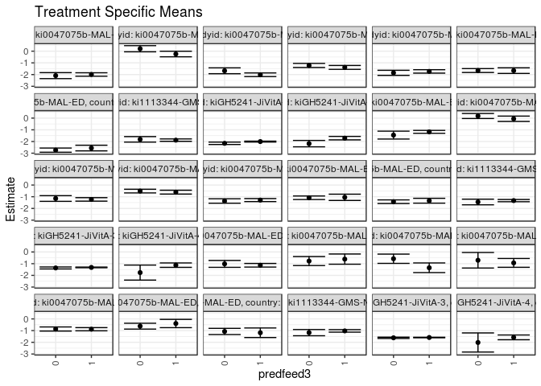

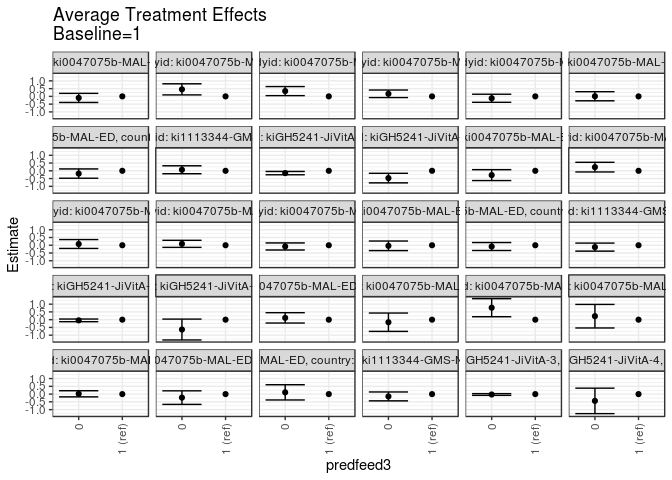

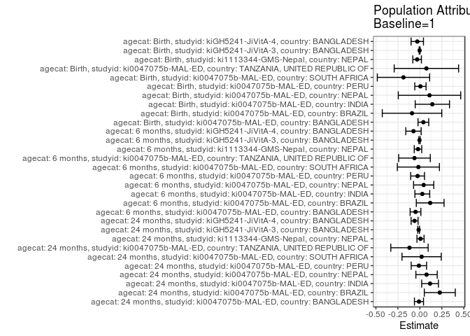

## Results Table

### Parameter: TSM

| agecat | studyid | country | intervention_level | baseline_level | estimate | ci_lower | ci_upper |
| --- | --- | --- | --- | --- | --- | --- | --- |
| Birth | ki0047075b-MAL-ED | BANGLADESH | 1 | NA | -1.1352586 | -1.2897991 | -0.9807181 |
| Birth | ki0047075b-MAL-ED | BANGLADESH | 0 | NA | -1.0182021 | -1.3122427 | -0.7241614 |
| Birth | ki0047075b-MAL-ED | BRAZIL | 1 | NA | -0.6108427 | -1.0472838 | -0.1744017 |
| Birth | ki0047075b-MAL-ED | BRAZIL | 0 | NA | -0.7755490 | -1.1614956 | -0.3896024 |
| Birth | ki0047075b-MAL-ED | INDIA | 1 | NA | -1.3499569 | -1.7633443 | -0.9365696 |
| Birth | ki0047075b-MAL-ED | INDIA | 0 | NA | -0.5785425 | -0.9737785 | -0.1833065 |
| Birth | ki0047075b-MAL-ED | NEPAL | 1 | NA | -0.9335419 | -1.3112760 | -0.5558078 |
| Birth | ki0047075b-MAL-ED | NEPAL | 0 | NA | -0.7088895 | -1.3732447 | -0.0445342 |
| Birth | ki0047075b-MAL-ED | PERU | 1 | NA | -0.8819000 | -1.0185470 | -0.7452531 |
| Birth | ki0047075b-MAL-ED | PERU | 0 | NA | -0.8624778 | -1.0386567 | -0.6862989 |
| Birth | ki0047075b-MAL-ED | SOUTH AFRICA | 1 | NA | -0.3935422 | -0.7474136 | -0.0396708 |
| Birth | ki0047075b-MAL-ED | SOUTH AFRICA | 0 | NA | -0.6204833 | -0.8692723 | -0.3716943 |
| Birth | ki0047075b-MAL-ED | TANZANIA, UNITED REPUBLIC OF | 1 | NA | -1.1834728 | -1.5930080 | -0.7739375 |
| Birth | ki0047075b-MAL-ED | TANZANIA, UNITED REPUBLIC OF | 0 | NA | -1.0715610 | -1.3376039 | -0.8055182 |
| Birth | ki1113344-GMS-Nepal | NEPAL | 1 | NA | -1.0247289 | -1.1318262 | -0.9176316 |
| Birth | ki1113344-GMS-Nepal | NEPAL | 0 | NA | -1.1742412 | -1.4398328 | -0.9086497 |
| Birth | kiGH5241-JiVitA-3 | BANGLADESH | 1 | NA | -1.5901667 | -1.6138216 | -1.5665119 |
| Birth | kiGH5241-JiVitA-3 | BANGLADESH | 0 | NA | -1.6151041 | -1.6699953 | -1.5602128 |
| Birth | kiGH5241-JiVitA-4 | BANGLADESH | 1 | NA | -1.5782245 | -1.7806964 | -1.3757527 |
| Birth | kiGH5241-JiVitA-4 | BANGLADESH | 0 | NA | -2.0158033 | -2.8331271 | -1.1984794 |
| 6 months | ki0047075b-MAL-ED | BANGLADESH | 1 | NA | -1.1751097 | -1.2986536 | -1.0515659 |
| 6 months | ki0047075b-MAL-ED | BANGLADESH | 0 | NA | -1.4522721 | -1.7889330 | -1.1156112 |
| 6 months | ki0047075b-MAL-ED | BRAZIL | 1 | NA | -0.0569795 | -0.2844104 | 0.1704514 |
| 6 months | ki0047075b-MAL-ED | BRAZIL | 0 | NA | 0.1793488 | -0.0334796 | 0.3921773 |
| 6 months | ki0047075b-MAL-ED | INDIA | 1 | NA | -1.2285706 | -1.3773417 | -1.0797995 |
| 6 months | ki0047075b-MAL-ED | INDIA | 0 | NA | -1.1492020 | -1.3917118 | -0.9066922 |
| 6 months | ki0047075b-MAL-ED | NEPAL | 1 | NA | -0.6071781 | -0.7716075 | -0.4427487 |
| 6 months | ki0047075b-MAL-ED | NEPAL | 0 | NA | -0.5168229 | -0.6738101 | -0.3598357 |
| 6 months | ki0047075b-MAL-ED | PERU | 1 | NA | -1.2852073 | -1.4133138 | -1.1571008 |
| 6 months | ki0047075b-MAL-ED | PERU | 0 | NA | -1.3641216 | -1.5544678 | -1.1737753 |
| 6 months | ki0047075b-MAL-ED | SOUTH AFRICA | 1 | NA | -1.0496126 | -1.3177914 | -0.7814339 |
| 6 months | ki0047075b-MAL-ED | SOUTH AFRICA | 0 | NA | -1.0867144 | -1.2385944 | -0.9348343 |
| 6 months | ki0047075b-MAL-ED | TANZANIA, UNITED REPUBLIC OF | 1 | NA | -1.3420562 | -1.5493525 | -1.1347600 |
| 6 months | ki0047075b-MAL-ED | TANZANIA, UNITED REPUBLIC OF | 0 | NA | -1.4240237 | -1.5789885 | -1.2690589 |
| 6 months | ki1113344-GMS-Nepal | NEPAL | 1 | NA | -1.3290587 | -1.4237462 | -1.2343711 |
| 6 months | ki1113344-GMS-Nepal | NEPAL | 0 | NA | -1.4498247 | -1.6920056 | -1.2076439 |
| 6 months | kiGH5241-JiVitA-3 | BANGLADESH | 1 | NA | -1.3200043 | -1.3492222 | -1.2907864 |
| 6 months | kiGH5241-JiVitA-3 | BANGLADESH | 0 | NA | -1.3644615 | -1.4489470 | -1.2799760 |
| 6 months | kiGH5241-JiVitA-4 | BANGLADESH | 1 | NA | -1.1269613 | -1.3154986 | -0.9384240 |
| 6 months | kiGH5241-JiVitA-4 | BANGLADESH | 0 | NA | -1.7631183 | -2.4048530 | -1.1213837 |
| 24 months | ki0047075b-MAL-ED | BANGLADESH | 1 | NA | -1.9918274 | -2.1386213 | -1.8450336 |
| 24 months | ki0047075b-MAL-ED | BANGLADESH | 0 | NA | -2.0901865 | -2.3457426 | -1.8346303 |
| 24 months | ki0047075b-MAL-ED | BRAZIL | 1 | NA | -0.2434826 | -0.4824166 | -0.0045485 |
| 24 months | ki0047075b-MAL-ED | BRAZIL | 0 | NA | 0.2095271 | -0.0529581 | 0.4720123 |
| 24 months | ki0047075b-MAL-ED | INDIA | 1 | NA | -2.0158209 | -2.1711472 | -1.8604945 |
| 24 months | ki0047075b-MAL-ED | INDIA | 0 | NA | -1.6753974 | -1.9265077 | -1.4242871 |
| 24 months | ki0047075b-MAL-ED | NEPAL | 1 | NA | -1.3874026 | -1.5541613 | -1.2206440 |
| 24 months | ki0047075b-MAL-ED | NEPAL | 0 | NA | -1.2205962 | -1.3955016 | -1.0456909 |
| 24 months | ki0047075b-MAL-ED | PERU | 1 | NA | -1.7304702 | -1.8764198 | -1.5845206 |
| 24 months | ki0047075b-MAL-ED | PERU | 0 | NA | -1.8511569 | -2.0690806 | -1.6332331 |
| 24 months | ki0047075b-MAL-ED | SOUTH AFRICA | 1 | NA | -1.6629601 | -1.9029106 | -1.4230096 |
| 24 months | ki0047075b-MAL-ED | SOUTH AFRICA | 0 | NA | -1.6547637 | -1.8213625 | -1.4881648 |
| 24 months | ki0047075b-MAL-ED | TANZANIA, UNITED REPUBLIC OF | 1 | NA | -2.5588833 | -2.8001049 | -2.3176616 |
| 24 months | ki0047075b-MAL-ED | TANZANIA, UNITED REPUBLIC OF | 0 | NA | -2.7382517 | -2.9167454 | -2.5597580 |
| 24 months | ki1113344-GMS-Nepal | NEPAL | 1 | NA | -1.8830151 | -1.9845893 | -1.7814410 |
| 24 months | ki1113344-GMS-Nepal | NEPAL | 0 | NA | -1.8160393 | -2.0518221 | -1.5802565 |
| 24 months | kiGH5241-JiVitA-3 | BANGLADESH | 1 | NA | -2.0052595 | -2.0430628 | -1.9674561 |
| 24 months | kiGH5241-JiVitA-3 | BANGLADESH | 0 | NA | -2.1540573 | -2.2578222 | -2.0502924 |
| 24 months | kiGH5241-JiVitA-4 | BANGLADESH | 1 | NA | -1.7129179 | -1.8607326 | -1.5651031 |
| 24 months | kiGH5241-JiVitA-4 | BANGLADESH | 0 | NA | -2.1818493 | -2.4538637 | -1.9098348 |

### Parameter: E(Y)

| agecat | studyid | country | intervention_level | baseline_level | estimate | ci_lower | ci_upper |
| --- | --- | --- | --- | --- | --- | --- | --- |
| Birth | ki0047075b-MAL-ED | BANGLADESH | NA | NA | -1.0949767 | -1.2319917 | -0.9579618 |
| Birth | ki0047075b-MAL-ED | BRAZIL | NA | NA | -0.6996491 | -0.9856018 | -0.4136965 |
| Birth | ki0047075b-MAL-ED | INDIA | NA | NA | -1.2075610 | -1.5261540 | -0.8889679 |
| Birth | ki0047075b-MAL-ED | NEPAL | NA | NA | -0.8234615 | -1.1896049 | -0.4573182 |
| Birth | ki0047075b-MAL-ED | PERU | NA | NA | -0.8753812 | -0.9932108 | -0.7575515 |
| Birth | ki0047075b-MAL-ED | SOUTH AFRICA | NA | NA | -0.5797000 | -0.7788298 | -0.3805702 |
| Birth | ki0047075b-MAL-ED | TANZANIA, UNITED REPUBLIC OF | NA | NA | -1.1086275 | -1.3310338 | -0.8862211 |
| Birth | ki1113344-GMS-Nepal | NEPAL | NA | NA | -1.0555240 | -1.1550843 | -0.9559638 |
| Birth | kiGH5241-JiVitA-3 | BANGLADESH | NA | NA | -1.5928457 | -1.6158667 | -1.5698248 |
| Birth | kiGH5241-JiVitA-4 | BANGLADESH | NA | NA | -1.6073276 | -1.8105798 | -1.4040753 |
| 6 months | ki0047075b-MAL-ED | BANGLADESH | NA | NA | -1.2242918 | -1.3439424 | -1.1046413 |
| 6 months | ki0047075b-MAL-ED | BRAZIL | NA | NA | 0.0609091 | -0.0944768 | 0.2162950 |
| 6 months | ki0047075b-MAL-ED | INDIA | NA | NA | -1.2002381 | -1.3274929 | -1.0729833 |
| 6 months | ki0047075b-MAL-ED | NEPAL | NA | NA | -0.5634068 | -0.6769687 | -0.4498449 |
| 6 months | ki0047075b-MAL-ED | PERU | NA | NA | -1.3108735 | -1.4182407 | -1.2035062 |
| 6 months | ki0047075b-MAL-ED | SOUTH AFRICA | NA | NA | -1.0662227 | -1.1965862 | -0.9358591 |
| 6 months | ki0047075b-MAL-ED | TANZANIA, UNITED REPUBLIC OF | NA | NA | -1.4030503 | -1.5292443 | -1.2768563 |
| 6 months | ki1113344-GMS-Nepal | NEPAL | NA | NA | -1.3499849 | -1.4387386 | -1.2612312 |
| 6 months | kiGH5241-JiVitA-3 | BANGLADESH | NA | NA | -1.3240051 | -1.3526414 | -1.2953689 |
| 6 months | kiGH5241-JiVitA-4 | BANGLADESH | NA | NA | -1.1994318 | -1.3808291 | -1.0180345 |
| 24 months | ki0047075b-MAL-ED | BANGLADESH | NA | NA | -2.0016585 | -2.1303297 | -1.8729874 |
| 24 months | ki0047075b-MAL-ED | BRAZIL | NA | NA | -0.0162939 | -0.1929098 | 0.1603221 |
| 24 months | ki0047075b-MAL-ED | INDIA | NA | NA | -1.8994059 | -2.0346781 | -1.7641337 |
| 24 months | ki0047075b-MAL-ED | NEPAL | NA | NA | -1.3109318 | -1.4313748 | -1.1904888 |
| 24 months | ki0047075b-MAL-ED | PERU | NA | NA | -1.7412963 | -1.8630698 | -1.6195228 |
| 24 months | ki0047075b-MAL-ED | SOUTH AFRICA | NA | NA | -1.6424525 | -1.7808926 | -1.5040124 |
| 24 months | ki0047075b-MAL-ED | TANZANIA, UNITED REPUBLIC OF | NA | NA | -2.6768207 | -2.8213178 | -2.5323235 |
| 24 months | ki1113344-GMS-Nepal | NEPAL | NA | NA | -1.8752995 | -1.9688053 | -1.7817937 |
| 24 months | kiGH5241-JiVitA-3 | BANGLADESH | NA | NA | -2.0187325 | -2.0554682 | -1.9819968 |
| 24 months | kiGH5241-JiVitA-4 | BANGLADESH | NA | NA | -1.7726490 | -1.9111913 | -1.6341067 |

### Parameter: ATE

| agecat | studyid | country | intervention_level | baseline_level | estimate | ci_lower | ci_upper |
| --- | --- | --- | --- | --- | --- | --- | --- |
| Birth | ki0047075b-MAL-ED | BANGLADESH | 1 | 1 | 0.0000000 | 0.0000000 | 0.0000000 |
| Birth | ki0047075b-MAL-ED | BANGLADESH | 0 | 1 | 0.1170565 | -0.2159353 | 0.4500483 |
| Birth | ki0047075b-MAL-ED | BRAZIL | 1 | 1 | 0.0000000 | 0.0000000 | 0.0000000 |
| Birth | ki0047075b-MAL-ED | BRAZIL | 0 | 1 | -0.1647063 | -0.7558075 | 0.4263950 |
| Birth | ki0047075b-MAL-ED | INDIA | 1 | 1 | 0.0000000 | 0.0000000 | 0.0000000 |
| Birth | ki0047075b-MAL-ED | INDIA | 0 | 1 | 0.7714145 | 0.1890925 | 1.3537364 |
| Birth | ki0047075b-MAL-ED | NEPAL | 1 | 1 | 0.0000000 | 0.0000000 | 0.0000000 |
| Birth | ki0047075b-MAL-ED | NEPAL | 0 | 1 | 0.2246525 | -0.5338207 | 0.9831257 |
| Birth | ki0047075b-MAL-ED | PERU | 1 | 1 | 0.0000000 | 0.0000000 | 0.0000000 |
| Birth | ki0047075b-MAL-ED | PERU | 0 | 1 | 0.0194222 | -0.1780744 | 0.2169189 |
| Birth | ki0047075b-MAL-ED | SOUTH AFRICA | 1 | 1 | 0.0000000 | 0.0000000 | 0.0000000 |
| Birth | ki0047075b-MAL-ED | SOUTH AFRICA | 0 | 1 | -0.2269411 | -0.6634809 | 0.2095986 |
| Birth | ki0047075b-MAL-ED | TANZANIA, UNITED REPUBLIC OF | 1 | 1 | 0.0000000 | 0.0000000 | 0.0000000 |
| Birth | ki0047075b-MAL-ED | TANZANIA, UNITED REPUBLIC OF | 0 | 1 | 0.1119118 | -0.3793626 | 0.6031861 |
| Birth | ki1113344-GMS-Nepal | NEPAL | 1 | 1 | 0.0000000 | 0.0000000 | 0.0000000 |
| Birth | ki1113344-GMS-Nepal | NEPAL | 0 | 1 | -0.1495123 | -0.4361653 | 0.1371407 |
| Birth | kiGH5241-JiVitA-3 | BANGLADESH | 1 | 1 | 0.0000000 | 0.0000000 | 0.0000000 |
| Birth | kiGH5241-JiVitA-3 | BANGLADESH | 0 | 1 | -0.0249373 | -0.0803499 | 0.0304753 |
| Birth | kiGH5241-JiVitA-4 | BANGLADESH | 1 | 1 | 0.0000000 | 0.0000000 | 0.0000000 |
| Birth | kiGH5241-JiVitA-4 | BANGLADESH | 0 | 1 | -0.4375787 | -1.2577989 | 0.3826415 |
| 6 months | ki0047075b-MAL-ED | BANGLADESH | 1 | 1 | 0.0000000 | 0.0000000 | 0.0000000 |
| 6 months | ki0047075b-MAL-ED | BANGLADESH | 0 | 1 | -0.2771624 | -0.6286216 | 0.0742968 |
| 6 months | ki0047075b-MAL-ED | BRAZIL | 1 | 1 | 0.0000000 | 0.0000000 | 0.0000000 |
| 6 months | ki0047075b-MAL-ED | BRAZIL | 0 | 1 | 0.2363284 | -0.0751534 | 0.5478101 |
| 6 months | ki0047075b-MAL-ED | INDIA | 1 | 1 | 0.0000000 | 0.0000000 | 0.0000000 |
| 6 months | ki0047075b-MAL-ED | INDIA | 0 | 1 | 0.0793686 | -0.2067762 | 0.3655134 |
| 6 months | ki0047075b-MAL-ED | NEPAL | 1 | 1 | 0.0000000 | 0.0000000 | 0.0000000 |
| 6 months | ki0047075b-MAL-ED | NEPAL | 0 | 1 | 0.0903552 | -0.1376579 | 0.3183684 |
| 6 months | ki0047075b-MAL-ED | PERU | 1 | 1 | 0.0000000 | 0.0000000 | 0.0000000 |
| 6 months | ki0047075b-MAL-ED | PERU | 0 | 1 | -0.0789142 | -0.3063736 | 0.1485451 |
| 6 months | ki0047075b-MAL-ED | SOUTH AFRICA | 1 | 1 | 0.0000000 | 0.0000000 | 0.0000000 |
| 6 months | ki0047075b-MAL-ED | SOUTH AFRICA | 0 | 1 | -0.0371018 | -0.3459197 | 0.2717162 |
| 6 months | ki0047075b-MAL-ED | TANZANIA, UNITED REPUBLIC OF | 1 | 1 | 0.0000000 | 0.0000000 | 0.0000000 |
| 6 months | ki0047075b-MAL-ED | TANZANIA, UNITED REPUBLIC OF | 0 | 1 | -0.0819675 | -0.3385094 | 0.1745745 |
| 6 months | ki1113344-GMS-Nepal | NEPAL | 1 | 1 | 0.0000000 | 0.0000000 | 0.0000000 |
| 6 months | ki1113344-GMS-Nepal | NEPAL | 0 | 1 | -0.1207661 | -0.3795511 | 0.1380189 |
| 6 months | kiGH5241-JiVitA-3 | BANGLADESH | 1 | 1 | 0.0000000 | 0.0000000 | 0.0000000 |
| 6 months | kiGH5241-JiVitA-3 | BANGLADESH | 0 | 1 | -0.0444572 | -0.1299354 | 0.0410211 |
| 6 months | kiGH5241-JiVitA-4 | BANGLADESH | 1 | 1 | 0.0000000 | 0.0000000 | 0.0000000 |
| 6 months | kiGH5241-JiVitA-4 | BANGLADESH | 0 | 1 | -0.6361570 | -1.3084485 | 0.0361344 |
| 24 months | ki0047075b-MAL-ED | BANGLADESH | 1 | 1 | 0.0000000 | 0.0000000 | 0.0000000 |
| 24 months | ki0047075b-MAL-ED | BANGLADESH | 0 | 1 | -0.0983590 | -0.3919655 | 0.1952475 |
| 24 months | ki0047075b-MAL-ED | BRAZIL | 1 | 1 | 0.0000000 | 0.0000000 | 0.0000000 |
| 24 months | ki0047075b-MAL-ED | BRAZIL | 0 | 1 | 0.4530097 | 0.0945161 | 0.8115032 |
| 24 months | ki0047075b-MAL-ED | INDIA | 1 | 1 | 0.0000000 | 0.0000000 | 0.0000000 |
| 24 months | ki0047075b-MAL-ED | INDIA | 0 | 1 | 0.3404235 | 0.0473606 | 0.6334863 |
| 24 months | ki0047075b-MAL-ED | NEPAL | 1 | 1 | 0.0000000 | 0.0000000 | 0.0000000 |
| 24 months | ki0047075b-MAL-ED | NEPAL | 0 | 1 | 0.1668064 | -0.0758174 | 0.4094302 |
| 24 months | ki0047075b-MAL-ED | PERU | 1 | 1 | 0.0000000 | 0.0000000 | 0.0000000 |
| 24 months | ki0047075b-MAL-ED | PERU | 0 | 1 | -0.1206867 | -0.3803535 | 0.1389802 |
| 24 months | ki0047075b-MAL-ED | SOUTH AFRICA | 1 | 1 | 0.0000000 | 0.0000000 | 0.0000000 |
| 24 months | ki0047075b-MAL-ED | SOUTH AFRICA | 0 | 1 | 0.0081965 | -0.2848687 | 0.3012617 |
| 24 months | ki0047075b-MAL-ED | TANZANIA, UNITED REPUBLIC OF | 1 | 1 | 0.0000000 | 0.0000000 | 0.0000000 |
| 24 months | ki0047075b-MAL-ED | TANZANIA, UNITED REPUBLIC OF | 0 | 1 | -0.1793684 | -0.4794857 | 0.1207489 |
| 24 months | ki1113344-GMS-Nepal | NEPAL | 1 | 1 | 0.0000000 | 0.0000000 | 0.0000000 |
| 24 months | ki1113344-GMS-Nepal | NEPAL | 0 | 1 | 0.0669758 | -0.1884241 | 0.3223757 |
| 24 months | kiGH5241-JiVitA-3 | BANGLADESH | 1 | 1 | 0.0000000 | 0.0000000 | 0.0000000 |
| 24 months | kiGH5241-JiVitA-3 | BANGLADESH | 0 | 1 | -0.1487979 | -0.2558152 | -0.0417805 |
| 24 months | kiGH5241-JiVitA-4 | BANGLADESH | 1 | 1 | 0.0000000 | 0.0000000 | 0.0000000 |
| 24 months | kiGH5241-JiVitA-4 | BANGLADESH | 0 | 1 | -0.4689314 | -0.7777309 | -0.1601319 |

### Parameter: PAR

| agecat | studyid | country | intervention_level | baseline_level | estimate | ci_lower | ci_upper |
| --- | --- | --- | --- | --- | --- | --- | --- |
| Birth | ki0047075b-MAL-ED | BANGLADESH | 1 | NA | 0.0402818 | -0.0207996 | 0.1013633 |
| Birth | ki0047075b-MAL-ED | BRAZIL | 1 | NA | -0.0888064 | -0.4274959 | 0.2498832 |
| Birth | ki0047075b-MAL-ED | INDIA | 1 | NA | 0.1423960 | -0.0528241 | 0.3376161 |
| Birth | ki0047075b-MAL-ED | NEPAL | 1 | NA | 0.1100804 | -0.2452620 | 0.4654227 |
| Birth | ki0047075b-MAL-ED | PERU | 1 | NA | 0.0065189 | -0.0577151 | 0.0707528 |
| Birth | ki0047075b-MAL-ED | SOUTH AFRICA | 1 | NA | -0.1861578 | -0.4838721 | 0.1115565 |
| Birth | ki0047075b-MAL-ED | TANZANIA, UNITED REPUBLIC OF | 1 | NA | 0.0748453 | -0.2918036 | 0.4414943 |
| Birth | ki1113344-GMS-Nepal | NEPAL | 1 | NA | -0.0307951 | -0.0796850 | 0.0180947 |
| Birth | kiGH5241-JiVitA-3 | BANGLADESH | 1 | NA | -0.0026790 | -0.0079484 | 0.0025904 |
| Birth | kiGH5241-JiVitA-4 | BANGLADESH | 1 | NA | -0.0291030 | -0.0996004 | 0.0413943 |
| 6 months | ki0047075b-MAL-ED | BANGLADESH | 1 | NA | -0.0491821 | -0.1104324 | 0.0120681 |
| 6 months | ki0047075b-MAL-ED | BRAZIL | 1 | NA | 0.1178886 | -0.0401034 | 0.2758806 |
| 6 months | ki0047075b-MAL-ED | INDIA | 1 | NA | 0.0283325 | -0.0559169 | 0.1125819 |
| 6 months | ki0047075b-MAL-ED | NEPAL | 1 | NA | 0.0437714 | -0.0710917 | 0.1586345 |
| 6 months | ki0047075b-MAL-ED | PERU | 1 | NA | -0.0256661 | -0.1043307 | 0.0529984 |
| 6 months | ki0047075b-MAL-ED | SOUTH AFRICA | 1 | NA | -0.0166101 | -0.2560323 | 0.2228122 |
| 6 months | ki0047075b-MAL-ED | TANZANIA, UNITED REPUBLIC OF | 1 | NA | -0.0609941 | -0.2408504 | 0.1188623 |
| 6 months | ki1113344-GMS-Nepal | NEPAL | 1 | NA | -0.0209262 | -0.0635897 | 0.0217373 |
| 6 months | kiGH5241-JiVitA-3 | BANGLADESH | 1 | NA | -0.0040008 | -0.0114979 | 0.0034963 |
| 6 months | kiGH5241-JiVitA-4 | BANGLADESH | 1 | NA | -0.0724705 | -0.1599359 | 0.0149948 |
| 24 months | ki0047075b-MAL-ED | BANGLADESH | 1 | NA | -0.0098311 | -0.0614205 | 0.0417583 |
| 24 months | ki0047075b-MAL-ED | BRAZIL | 1 | NA | 0.2271887 | 0.0507528 | 0.4036246 |
| 24 months | ki0047075b-MAL-ED | INDIA | 1 | NA | 0.1164149 | 0.0211546 | 0.2116753 |
| 24 months | ki0047075b-MAL-ED | NEPAL | 1 | NA | 0.0764708 | -0.0449582 | 0.1978998 |
| 24 months | ki0047075b-MAL-ED | PERU | 1 | NA | -0.0108261 | -0.0983041 | 0.0766520 |
| 24 months | ki0047075b-MAL-ED | SOUTH AFRICA | 1 | NA | 0.0205077 | -0.2029675 | 0.2439828 |
| 24 months | ki0047075b-MAL-ED | TANZANIA, UNITED REPUBLIC OF | 1 | NA | -0.1179374 | -0.3304434 | 0.0945687 |
| 24 months | ki1113344-GMS-Nepal | NEPAL | 1 | NA | 0.0077156 | -0.0327258 | 0.0481571 |
| 24 months | kiGH5241-JiVitA-3 | BANGLADESH | 1 | NA | -0.0134730 | -0.0230038 | -0.0039422 |
| 24 months | kiGH5241-JiVitA-4 | BANGLADESH | 1 | NA | -0.0597312 | -0.0993996 | -0.0200627 |